# Risk Factor Analysis

## Outcome Variable

**Outcome Variable:** whz

## Predictor Variables

**Intervention Variable:** vagbrth

**Adjustment Set:**

- arm
- sex
- W_mage
- meducyrs
- feducyrs
- W_mhtcm
- single
- brthmon
- W_parity
- delta_W_mage
- delta_meducyrs
- delta_feducyrs
- delta_W_mhtcm
- delta_single
- delta_brthmon
- delta_W_parity

## Stratifying Variables

The analysis was stratified on these variable(s):

- agecat
- studyid
- country

## Data Summary

| agecat | studyid | country | vagbrth | n_cell | n |
| --- | --- | --- | --- | --- | --- |
| Birth | ki1000108-CMC-V-BCS-2002 | INDIA | 0 | 10 | 88 |
| Birth | ki1000108-CMC-V-BCS-2002 | INDIA | 1 | 78 | 88 |
| Birth | ki1000108-IRC | INDIA | 0 | 66 | 343 |
| Birth | ki1000108-IRC | INDIA | 1 | 277 | 343 |
| Birth | ki1017093c-NIH-Crypto | BANGLADESH | 0 | 1 | 17 |
| Birth | ki1017093c-NIH-Crypto | BANGLADESH | 1 | 16 | 17 |
| Birth | ki1119695-PROBIT | BELARUS | 0 | 1593 | 13824 |
| Birth | ki1119695-PROBIT | BELARUS | 1 | 12231 | 13824 |
| Birth | ki1126311-ZVITAMBO | ZIMBABWE | 0 | 1099 | 12813 |
| Birth | ki1126311-ZVITAMBO | ZIMBABWE | 1 | 11714 | 12813 |
| Birth | kiGH5241-JiVitA-3 | BANGLADESH | 0 | 2 | 15689 |
| Birth | kiGH5241-JiVitA-3 | BANGLADESH | 1 | 15687 | 15689 |
| Birth | kiGH5241-JiVitA-4 | BANGLADESH | 0 | 1 | 683 |
| Birth | kiGH5241-JiVitA-4 | BANGLADESH | 1 | 682 | 683 |
| 6 months | ki1000108-CMC-V-BCS-2002 | INDIA | 0 | 25 | 368 |
| 6 months | ki1000108-CMC-V-BCS-2002 | INDIA | 1 | 343 | 368 |
| 6 months | ki1000108-IRC | INDIA | 0 | 68 | 408 |
| 6 months | ki1000108-IRC | INDIA | 1 | 340 | 408 |
| 6 months | ki1017093b-PROVIDE | BANGLADESH | 0 | 134 | 582 |
| 6 months | ki1017093b-PROVIDE | BANGLADESH | 1 | 448 | 582 |
| 6 months | ki1017093c-NIH-Crypto | BANGLADESH | 0 | 187 | 457 |
| 6 months | ki1017093c-NIH-Crypto | BANGLADESH | 1 | 270 | 457 |
| 6 months | ki1066203-TanzaniaChild2 | TANZANIA, UNITED REPUBLIC OF | 0 | 189 | 2004 |
| 6 months | ki1066203-TanzaniaChild2 | TANZANIA, UNITED REPUBLIC OF | 1 | 1815 | 2004 |
| 6 months | ki1119695-PROBIT | BELARUS | 0 | 1798 | 15757 |
| 6 months | ki1119695-PROBIT | BELARUS | 1 | 13959 | 15757 |
| 6 months | ki1126311-ZVITAMBO | ZIMBABWE | 0 | 706 | 8197 |
| 6 months | ki1126311-ZVITAMBO | ZIMBABWE | 1 | 7491 | 8197 |
| 6 months | kiGH5241-JiVitA-3 | BANGLADESH | 0 | 1075 | 16705 |
| 6 months | kiGH5241-JiVitA-3 | BANGLADESH | 1 | 15630 | 16705 |
| 6 months | kiGH5241-JiVitA-4 | BANGLADESH | 0 | 337 | 4056 |
| 6 months | kiGH5241-JiVitA-4 | BANGLADESH | 1 | 3719 | 4056 |
| 24 months | ki1000108-CMC-V-BCS-2002 | INDIA | 0 | 25 | 372 |
| 24 months | ki1000108-CMC-V-BCS-2002 | INDIA | 1 | 347 | 372 |
| 24 months | ki1000108-IRC | INDIA | 0 | 69 | 409 |
| 24 months | ki1000108-IRC | INDIA | 1 | 340 | 409 |
| 24 months | ki1017093b-PROVIDE | BANGLADESH | 0 | 137 | 578 |
| 24 months | ki1017093b-PROVIDE | BANGLADESH | 1 | 441 | 578 |
| 24 months | ki1017093c-NIH-Crypto | BANGLADESH | 0 | 99 | 260 |
| 24 months | ki1017093c-NIH-Crypto | BANGLADESH | 1 | 161 | 260 |
| 24 months | ki1066203-TanzaniaChild2 | TANZANIA, UNITED REPUBLIC OF | 0 | 2 | 6 |
| 24 months | ki1066203-TanzaniaChild2 | TANZANIA, UNITED REPUBLIC OF | 1 | 4 | 6 |
| 24 months | ki1119695-PROBIT | BELARUS | 0 | 463 | 3971 |
| 24 months | ki1119695-PROBIT | BELARUS | 1 | 3508 | 3971 |
| 24 months | ki1126311-ZVITAMBO | ZIMBABWE | 0 | 28 | 417 |
| 24 months | ki1126311-ZVITAMBO | ZIMBABWE | 1 | 389 | 417 |
| 24 months | kiGH5241-JiVitA-3 | BANGLADESH | 0 | 475 | 8555 |
| 24 months | kiGH5241-JiVitA-3 | BANGLADESH | 1 | 8080 | 8555 |
| 24 months | kiGH5241-JiVitA-4 | BANGLADESH | 0 | 323 | 4008 |
| 24 months | kiGH5241-JiVitA-4 | BANGLADESH | 1 | 3685 | 4008 |

The following strata were considered:

- agecat: 24 months, studyid: ki1000108-CMC-V-BCS-2002, country: INDIA
- agecat: 24 months, studyid: ki1000108-IRC, country: INDIA
- agecat: 24 months, studyid: ki1017093b-PROVIDE, country: BANGLADESH
- agecat: 24 months, studyid: ki1017093c-NIH-Crypto, country: BANGLADESH
- agecat: 24 months, studyid: ki1066203-TanzaniaChild2, country: TANZANIA, UNITED REPUBLIC OF
- agecat: 24 months, studyid: ki1119695-PROBIT, country: BELARUS
- agecat: 24 months, studyid: ki1126311-ZVITAMBO, country: ZIMBABWE
- agecat: 24 months, studyid: kiGH5241-JiVitA-3, country: BANGLADESH
- agecat: 24 months, studyid: kiGH5241-JiVitA-4, country: BANGLADESH
- agecat: 6 months, studyid: ki1000108-CMC-V-BCS-2002, country: INDIA
- agecat: 6 months, studyid: ki1000108-IRC, country: INDIA
- agecat: 6 months, studyid: ki1017093b-PROVIDE, country: BANGLADESH
- agecat: 6 months, studyid: ki1017093c-NIH-Crypto, country: BANGLADESH
- agecat: 6 months, studyid: ki1066203-TanzaniaChild2, country: TANZANIA, UNITED REPUBLIC OF
- agecat: 6 months, studyid: ki1119695-PROBIT, country: BELARUS
- agecat: 6 months, studyid: ki1126311-ZVITAMBO, country: ZIMBABWE
- agecat: 6 months, studyid: kiGH5241-JiVitA-3, country: BANGLADESH
- agecat: 6 months, studyid: kiGH5241-JiVitA-4, country: BANGLADESH
- agecat: Birth, studyid: ki1000108-CMC-V-BCS-2002, country: INDIA
- agecat: Birth, studyid: ki1000108-IRC, country: INDIA
- agecat: Birth, studyid: ki1017093c-NIH-Crypto, country: BANGLADESH
- agecat: Birth, studyid: ki1119695-PROBIT, country: BELARUS
- agecat: Birth, studyid: ki1126311-ZVITAMBO, country: ZIMBABWE
- agecat: Birth, studyid: kiGH5241-JiVitA-3, country: BANGLADESH
- agecat: Birth, studyid: kiGH5241-JiVitA-4, country: BANGLADESH

### Dropped Strata

Some strata were dropped due to rare outcomes:

- agecat: Birth, studyid: ki1017093c-NIH-Crypto, country: BANGLADESH
- agecat: Birth, studyid: kiGH5241-JiVitA-3, country: BANGLADESH
- agecat: Birth, studyid: kiGH5241-JiVitA-4, country: BANGLADESH
- agecat: 24 months, studyid: ki1066203-TanzaniaChild2, country: TANZANIA, UNITED REPUBLIC OF

## Methods Detail

We’re interested in the causal parameters $E[Y_a]$ for all values of $a \in \mathcal{A}$. These parameters represent the mean outcome if, possibly contrary to fact, we intervened to set all units to have $A=a$. Under the randomization and positivity assumptions, these are identified by the statistical parameters $\psi_a=E_W[E_{Y|A,W}(Y|A=a,W)]$. In addition, we’re interested in the mean of $Y$, $E[Y]$ under no intervention (the observed mean). We will estimate these parameters by using SuperLearner to fit the relevant likelihood factors – $E_{Y|A,W}(Y|A=a,W)$ and $p(A=a|W)$, and then updating our likelihood fit using a joint TMLE.

For unadjusted analyses ($W=\{\}$), initial likelihoods were estimated using Lrnr_glm to estimate the simple $E(Y|A)$ and Lrnr_mean to estimate $p(A)$. For adjusted analyses, a small library containing Lrnr_glmnet, Lrnr_xgboost, and Lrnr_mean was used.

Having estimated these parameters, we will then use the delta method to estimate relative risks and attributable risks relative to a prespecified baseline level of $A$.

# Results Detail

## Results Plots

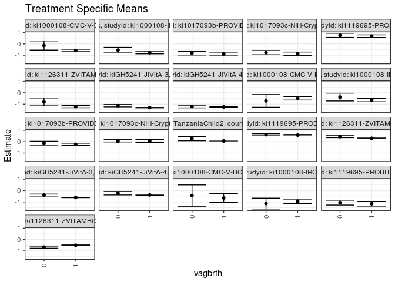

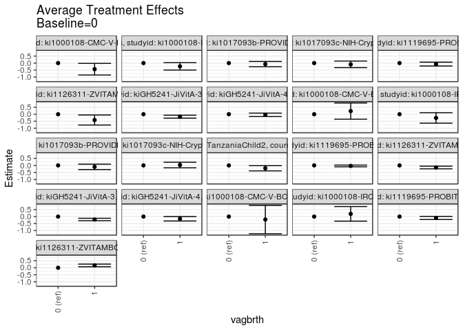

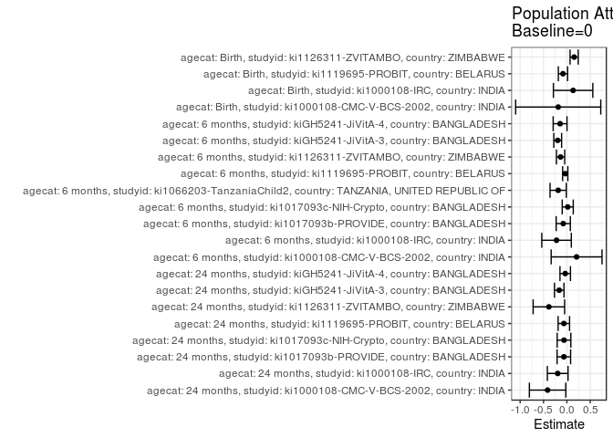

## Results Table

### Parameter: TSM

| agecat | studyid | country | intervention_level | baseline_level | estimate | ci_lower | ci_upper |
| --- | --- | --- | --- | --- | --- | --- | --- |
| Birth | ki1000108-CMC-V-BCS-2002 | INDIA | 0 | NA | -0.4421128 | -1.3829396 | 0.4987140 |
| Birth | ki1000108-CMC-V-BCS-2002 | INDIA | 1 | NA | -0.6529415 | -1.0306696 | -0.2752134 |
| Birth | ki1000108-IRC | INDIA | 0 | NA | -1.1443807 | -1.6231758 | -0.6655856 |
| Birth | ki1000108-IRC | INDIA | 1 | NA | -0.9500036 | -1.1509252 | -0.7490820 |
| Birth | ki1119695-PROBIT | BELARUS | 0 | NA | -1.0630462 | -1.2768244 | -0.8492681 |
| Birth | ki1119695-PROBIT | BELARUS | 1 | NA | -1.1582162 | -1.3703811 | -0.9460513 |
| Birth | ki1126311-ZVITAMBO | ZIMBABWE | 0 | NA | -0.6725636 | -0.7637227 | -0.5814045 |
| Birth | ki1126311-ZVITAMBO | ZIMBABWE | 1 | NA | -0.5055702 | -0.5327200 | -0.4784204 |
| 6 months | ki1000108-CMC-V-BCS-2002 | INDIA | 0 | NA | -0.7110357 | -1.2688647 | -0.1532067 |
| 6 months | ki1000108-CMC-V-BCS-2002 | INDIA | 1 | NA | -0.4856832 | -0.6436223 | -0.3277441 |
| 6 months | ki1000108-IRC | INDIA | 0 | NA | -0.3781535 | -0.7208213 | -0.0354857 |
| 6 months | ki1000108-IRC | INDIA | 1 | NA | -0.6412444 | -0.7906239 | -0.4918649 |
| 6 months | ki1017093b-PROVIDE | BANGLADESH | 0 | NA | -0.1312457 | -0.3000354 | 0.0375440 |
| 6 months | ki1017093b-PROVIDE | BANGLADESH | 1 | NA | -0.2345292 | -0.3328243 | -0.1362342 |
| 6 months | ki1017093c-NIH-Crypto | BANGLADESH | 0 | NA | 0.0326871 | -0.1115412 | 0.1769154 |
| 6 months | ki1017093c-NIH-Crypto | BANGLADESH | 1 | NA | 0.0634634 | -0.0723874 | 0.1993142 |
| 6 months | ki1066203-TanzaniaChild2 | TANZANIA, UNITED REPUBLIC OF | 0 | NA | 0.2625301 | 0.0801094 | 0.4449508 |
| 6 months | ki1066203-TanzaniaChild2 | TANZANIA, UNITED REPUBLIC OF | 1 | NA | 0.0608861 | 0.0054811 | 0.1162911 |
| 6 months | ki1119695-PROBIT | BELARUS | 0 | NA | 0.6135887 | 0.5243318 | 0.7028455 |
| 6 months | ki1119695-PROBIT | BELARUS | 1 | NA | 0.5760872 | 0.5163733 | 0.6358012 |
| 6 months | ki1126311-ZVITAMBO | ZIMBABWE | 0 | NA | 0.4401215 | 0.3480301 | 0.5322129 |
| 6 months | ki1126311-ZVITAMBO | ZIMBABWE | 1 | NA | 0.2920485 | 0.2646760 | 0.3194209 |
| 6 months | kiGH5241-JiVitA-3 | BANGLADESH | 0 | NA | -0.3975586 | -0.4849725 | -0.3101446 |
| 6 months | kiGH5241-JiVitA-3 | BANGLADESH | 1 | NA | -0.6058431 | -0.6255168 | -0.5861693 |
| 6 months | kiGH5241-JiVitA-4 | BANGLADESH | 0 | NA | -0.2308743 | -0.3846314 | -0.0771173 |
| 6 months | kiGH5241-JiVitA-4 | BANGLADESH | 1 | NA | -0.3867636 | -0.4315135 | -0.3420136 |
| 24 months | ki1000108-CMC-V-BCS-2002 | INDIA | 0 | NA | -0.1445281 | -0.5470264 | 0.2579702 |
| 24 months | ki1000108-CMC-V-BCS-2002 | INDIA | 1 | NA | -0.5809216 | -0.6855601 | -0.4762831 |
| 24 months | ki1000108-IRC | INDIA | 0 | NA | -0.5497305 | -0.7969346 | -0.3025264 |
| 24 months | ki1000108-IRC | INDIA | 1 | NA | -0.7841503 | -0.8801478 | -0.6881528 |
| 24 months | ki1017093b-PROVIDE | BANGLADESH | 0 | NA | -0.8234467 | -0.9849482 | -0.6619452 |
| 24 months | ki1017093b-PROVIDE | BANGLADESH | 1 | NA | -0.8961732 | -0.9925394 | -0.7998070 |
| 24 months | ki1017093c-NIH-Crypto | BANGLADESH | 0 | NA | -0.7731424 | -0.9594793 | -0.5868054 |
| 24 months | ki1017093c-NIH-Crypto | BANGLADESH | 1 | NA | -0.8655609 | -1.0097987 | -0.7213231 |
| 24 months | ki1119695-PROBIT | BELARUS | 0 | NA | 0.7507410 | 0.5736005 | 0.9278815 |
| 24 months | ki1119695-PROBIT | BELARUS | 1 | NA | 0.6785901 | 0.5682874 | 0.7888928 |
| 24 months | ki1126311-ZVITAMBO | ZIMBABWE | 0 | NA | -0.8021574 | -1.1468176 | -0.4574972 |
| 24 months | ki1126311-ZVITAMBO | ZIMBABWE | 1 | NA | -1.2162611 | -1.3214073 | -1.1111148 |
| 24 months | kiGH5241-JiVitA-3 | BANGLADESH | 0 | NA | -1.1350081 | -1.2395269 | -1.0304893 |
| 24 months | kiGH5241-JiVitA-3 | BANGLADESH | 1 | NA | -1.3089987 | -1.3328478 | -1.2851496 |
| 24 months | kiGH5241-JiVitA-4 | BANGLADESH | 0 | NA | -1.2084104 | -1.3255587 | -1.0912621 |
| 24 months | kiGH5241-JiVitA-4 | BANGLADESH | 1 | NA | -1.2472285 | -1.2827089 | -1.2117480 |

### Parameter: E(Y)

| agecat | studyid | country | intervention_level | baseline_level | estimate | ci_lower | ci_upper |
| --- | --- | --- | --- | --- | --- | --- | --- |
| Birth | ki1000108-CMC-V-BCS-2002 | INDIA | NA | NA | -0.6275000 | -0.9746292 | -0.2803708 |
| Birth | ki1000108-IRC | INDIA | NA | NA | -1.0105831 | -1.1973019 | -0.8238643 |
| Birth | ki1119695-PROBIT | BELARUS | NA | NA | -1.1463469 | -1.3562674 | -0.9364264 |
| Birth | ki1126311-ZVITAMBO | ZIMBABWE | NA | NA | -0.5165387 | -0.5425056 | -0.4905717 |
| 6 months | ki1000108-CMC-V-BCS-2002 | INDIA | NA | NA | -0.5026766 | -0.6536848 | -0.3516685 |
| 6 months | ki1000108-IRC | INDIA | NA | NA | -0.5989297 | -0.7344491 | -0.4634104 |
| 6 months | ki1017093b-PROVIDE | BANGLADESH | NA | NA | -0.2083706 | -0.2927992 | -0.1239419 |
| 6 months | ki1017093c-NIH-Crypto | BANGLADESH | NA | NA | 0.0515536 | -0.0469240 | 0.1500313 |
| 6 months | ki1066203-TanzaniaChild2 | TANZANIA, UNITED REPUBLIC OF | NA | NA | 0.0769382 | 0.0241090 | 0.1297674 |
| 6 months | ki1119695-PROBIT | BELARUS | NA | NA | 0.5789633 | 0.5190130 | 0.6389137 |
| 6 months | ki1126311-ZVITAMBO | ZIMBABWE | NA | NA | 0.3058247 | 0.2796439 | 0.3320055 |
| 6 months | kiGH5241-JiVitA-3 | BANGLADESH | NA | NA | -0.5935070 | -0.6130727 | -0.5739413 |
| 6 months | kiGH5241-JiVitA-4 | BANGLADESH | NA | NA | -0.3758037 | -0.4184544 | -0.3331531 |
| 24 months | ki1000108-CMC-V-BCS-2002 | INDIA | NA | NA | -0.5571505 | -0.6585247 | -0.4557763 |
| 24 months | ki1000108-IRC | INDIA | NA | NA | -0.7458150 | -0.8368180 | -0.6548120 |
| 24 months | ki1017093b-PROVIDE | BANGLADESH | NA | NA | -0.8879412 | -0.9708680 | -0.8050144 |
| 24 months | ki1017093c-NIH-Crypto | BANGLADESH | NA | NA | -0.8343077 | -0.9482310 | -0.7203844 |
| 24 months | ki1119695-PROBIT | BELARUS | NA | NA | 0.6863435 | 0.5745700 | 0.7981170 |
| 24 months | ki1126311-ZVITAMBO | ZIMBABWE | NA | NA | -1.1870743 | -1.2881393 | -1.0860094 |
| 24 months | kiGH5241-JiVitA-3 | BANGLADESH | NA | NA | -1.2983928 | -1.3216893 | -1.2750962 |
| 24 months | kiGH5241-JiVitA-4 | BANGLADESH | NA | NA | -1.2433658 | -1.2774681 | -1.2092634 |

### Parameter: ATE

| agecat | studyid | country | intervention_level | baseline_level | estimate | ci_lower | ci_upper |
| --- | --- | --- | --- | --- | --- | --- | --- |
| Birth | ki1000108-CMC-V-BCS-2002 | INDIA | 0 | 0 | 0.0000000 | 0.0000000 | 0.0000000 |
| Birth | ki1000108-CMC-V-BCS-2002 | INDIA | 1 | 0 | -0.2108287 | -1.2265317 | 0.8048742 |
| Birth | ki1000108-IRC | INDIA | 0 | 0 | 0.0000000 | 0.0000000 | 0.0000000 |
| Birth | ki1000108-IRC | INDIA | 1 | 0 | 0.1943771 | -0.3257609 | 0.7145151 |
| Birth | ki1119695-PROBIT | BELARUS | 0 | 0 | 0.0000000 | 0.0000000 | 0.0000000 |
| Birth | ki1119695-PROBIT | BELARUS | 1 | 0 | -0.0951700 | -0.2063565 | 0.0160165 |
| Birth | ki1126311-ZVITAMBO | ZIMBABWE | 0 | 0 | 0.0000000 | 0.0000000 | 0.0000000 |
| Birth | ki1126311-ZVITAMBO | ZIMBABWE | 1 | 0 | 0.1669935 | 0.0719251 | 0.2620619 |
| 6 months | ki1000108-CMC-V-BCS-2002 | INDIA | 0 | 0 | 0.0000000 | 0.0000000 | 0.0000000 |
| 6 months | ki1000108-CMC-V-BCS-2002 | INDIA | 1 | 0 | 0.2253525 | -0.3531956 | 0.8039007 |
| 6 months | ki1000108-IRC | INDIA | 0 | 0 | 0.0000000 | 0.0000000 | 0.0000000 |
| 6 months | ki1000108-IRC | INDIA | 1 | 0 | -0.2630909 | -0.6379490 | 0.1117672 |
| 6 months | ki1017093b-PROVIDE | BANGLADESH | 0 | 0 | 0.0000000 | 0.0000000 | 0.0000000 |
| 6 months | ki1017093b-PROVIDE | BANGLADESH | 1 | 0 | -0.1032835 | -0.2985934 | 0.0920263 |
| 6 months | ki1017093c-NIH-Crypto | BANGLADESH | 0 | 0 | 0.0000000 | 0.0000000 | 0.0000000 |
| 6 months | ki1017093c-NIH-Crypto | BANGLADESH | 1 | 0 | 0.0307763 | -0.1682390 | 0.2297916 |
| 6 months | ki1066203-TanzaniaChild2 | TANZANIA, UNITED REPUBLIC OF | 0 | 0 | 0.0000000 | 0.0000000 | 0.0000000 |
| 6 months | ki1066203-TanzaniaChild2 | TANZANIA, UNITED REPUBLIC OF | 1 | 0 | -0.2016440 | -0.3923568 | -0.0109312 |
| 6 months | ki1119695-PROBIT | BELARUS | 0 | 0 | 0.0000000 | 0.0000000 | 0.0000000 |
| 6 months | ki1119695-PROBIT | BELARUS | 1 | 0 | -0.0375014 | -0.0997867 | 0.0247838 |
| 6 months | ki1126311-ZVITAMBO | ZIMBABWE | 0 | 0 | 0.0000000 | 0.0000000 | 0.0000000 |
| 6 months | ki1126311-ZVITAMBO | ZIMBABWE | 1 | 0 | -0.1480731 | -0.2441655 | -0.0519806 |
| 6 months | kiGH5241-JiVitA-3 | BANGLADESH | 0 | 0 | 0.0000000 | 0.0000000 | 0.0000000 |
| 6 months | kiGH5241-JiVitA-3 | BANGLADESH | 1 | 0 | -0.2082845 | -0.2958377 | -0.1207312 |
| 6 months | kiGH5241-JiVitA-4 | BANGLADESH | 0 | 0 | 0.0000000 | 0.0000000 | 0.0000000 |
| 6 months | kiGH5241-JiVitA-4 | BANGLADESH | 1 | 0 | -0.1558892 | -0.3169230 | 0.0051446 |
| 24 months | ki1000108-CMC-V-BCS-2002 | INDIA | 0 | 0 | 0.0000000 | 0.0000000 | 0.0000000 |
| 24 months | ki1000108-CMC-V-BCS-2002 | INDIA | 1 | 0 | -0.4363935 | -0.8526145 | -0.0201725 |
| 24 months | ki1000108-IRC | INDIA | 0 | 0 | 0.0000000 | 0.0000000 | 0.0000000 |
| 24 months | ki1000108-IRC | INDIA | 1 | 0 | -0.2344198 | -0.4996193 | 0.0307796 |
| 24 months | ki1017093b-PROVIDE | BANGLADESH | 0 | 0 | 0.0000000 | 0.0000000 | 0.0000000 |
| 24 months | ki1017093b-PROVIDE | BANGLADESH | 1 | 0 | -0.0727265 | -0.2600186 | 0.1145656 |
| 24 months | ki1017093c-NIH-Crypto | BANGLADESH | 0 | 0 | 0.0000000 | 0.0000000 | 0.0000000 |
| 24 months | ki1017093c-NIH-Crypto | BANGLADESH | 1 | 0 | -0.0924185 | -0.3277918 | 0.1429547 |
| 24 months | ki1119695-PROBIT | BELARUS | 0 | 0 | 0.0000000 | 0.0000000 | 0.0000000 |
| 24 months | ki1119695-PROBIT | BELARUS | 1 | 0 | -0.0721509 | -0.2097086 | 0.0654069 |
| 24 months | ki1126311-ZVITAMBO | ZIMBABWE | 0 | 0 | 0.0000000 | 0.0000000 | 0.0000000 |
| 24 months | ki1126311-ZVITAMBO | ZIMBABWE | 1 | 0 | -0.4141037 | -0.7746417 | -0.0535656 |
| 24 months | kiGH5241-JiVitA-3 | BANGLADESH | 0 | 0 | 0.0000000 | 0.0000000 | 0.0000000 |
| 24 months | kiGH5241-JiVitA-3 | BANGLADESH | 1 | 0 | -0.1739906 | -0.2805277 | -0.0674535 |
| 24 months | kiGH5241-JiVitA-4 | BANGLADESH | 0 | 0 | 0.0000000 | 0.0000000 | 0.0000000 |
| 24 months | kiGH5241-JiVitA-4 | BANGLADESH | 1 | 0 | -0.0388180 | -0.1607480 | 0.0831120 |

### Parameter: PAR

| agecat | studyid | country | intervention_level | baseline_level | estimate | ci_lower | ci_upper |
| --- | --- | --- | --- | --- | --- | --- | --- |
| Birth | ki1000108-CMC-V-BCS-2002 | INDIA | 0 | NA | -0.1853872 | -1.0963766 | 0.7256022 |
| Birth | ki1000108-IRC | INDIA | 0 | NA | 0.1337976 | -0.2881431 | 0.5557383 |
| Birth | ki1119695-PROBIT | BELARUS | 0 | NA | -0.0833007 | -0.1818712 | 0.0152698 |
| Birth | ki1126311-ZVITAMBO | ZIMBABWE | 0 | NA | 0.1560250 | 0.0686708 | 0.2433791 |
| 6 months | ki1000108-CMC-V-BCS-2002 | INDIA | 0 | NA | 0.2083590 | -0.3360551 | 0.7527732 |
| 6 months | ki1000108-IRC | INDIA | 0 | NA | -0.2207762 | -0.5371444 | 0.0955920 |
| 6 months | ki1017093b-PROVIDE | BANGLADESH | 0 | NA | -0.0771249 | -0.2287992 | 0.0745494 |
| 6 months | ki1017093c-NIH-Crypto | BANGLADESH | 0 | NA | 0.0188665 | -0.0992420 | 0.1369750 |
| 6 months | ki1066203-TanzaniaChild2 | TANZANIA, UNITED REPUBLIC OF | 0 | NA | -0.1855919 | -0.3593001 | -0.0118837 |
| 6 months | ki1119695-PROBIT | BELARUS | 0 | NA | -0.0346253 | -0.0905361 | 0.0212854 |
| 6 months | ki1126311-ZVITAMBO | ZIMBABWE | 0 | NA | -0.1342968 | -0.2224489 | -0.0461447 |
| 6 months | kiGH5241-JiVitA-3 | BANGLADESH | 0 | NA | -0.1959485 | -0.2794676 | -0.1124293 |
| 6 months | kiGH5241-JiVitA-4 | BANGLADESH | 0 | NA | -0.1449294 | -0.2930259 | 0.0031671 |
| 24 months | ki1000108-CMC-V-BCS-2002 | INDIA | 0 | NA | -0.4126225 | -0.8023479 | -0.0228971 |
| 24 months | ki1000108-IRC | INDIA | 0 | NA | -0.1960845 | -0.4175460 | 0.0253770 |
| 24 months | ki1017093b-PROVIDE | BANGLADESH | 0 | NA | -0.0644945 | -0.2093983 | 0.0804094 |
| 24 months | ki1017093c-NIH-Crypto | BANGLADESH | 0 | NA | -0.0611653 | -0.2073215 | 0.0849908 |
| 24 months | ki1119695-PROBIT | BELARUS | 0 | NA | -0.0643975 | -0.1868368 | 0.0580418 |
| 24 months | ki1126311-ZVITAMBO | ZIMBABWE | 0 | NA | -0.3849169 | -0.7218053 | -0.0480286 |
| 24 months | kiGH5241-JiVitA-3 | BANGLADESH | 0 | NA | -0.1633846 | -0.2651326 | -0.0616367 |
| 24 months | kiGH5241-JiVitA-4 | BANGLADESH | 0 | NA | -0.0349553 | -0.1471939 | 0.0772832 |